# Machine Learning Project

### Extracting Important Features from Clusters

```r
centers <- kmeans_model$centers

# Calculate the range (max - min) for each feature
feature_ranges <- apply(centers, 2, function(x) max(x) - min(x))

# Sort the features by their range (descending order)
feature_ranges_sorted <- sort(feature_ranges, decreasing = TRUE)

feature_ranges_sorted
```

```
##  KitchenAbvGr     X1stFlrSF     X2ndFlrSF   TotalBsmtSF  TotRmsAbvGrd
##     4.6933538     2.0745730     2.0617246     2.0332200     1.8576901
##    GarageCars     YearBuilt  BedroomAbvGr    GarageArea     BsmtUnfSF
##     1.7503981     1.7317592     1.6988999     1.6801577     1.6269789
##      FullBath     GrLivArea      HalfBath  YearRemodAdd  BsmtFullBath
##     1.5828882     1.5755928     1.5255127     1.5048435     1.2818629
##    BsmtFinSF1    Fireplaces    MasVnrArea   LotFrontage    WoodDeckSF
##     1.1150137     1.0834335     0.9653702     0.9050892     0.8348706
##   OpenPorchSF       LotArea    BsmtFinSF2 EnclosedPorch   ScreenPorch
##     0.7398410     0.7014345     0.6252513     0.6239674     0.4642166
##  BsmtHalfBath       MiscVal    X3SsnPorch  LowQualFinSF      PoolArea
##     0.4189822     0.2934248     0.2776250     0.2380399     0.1371215
##        YrSold
##     0.1269179
```

#### Visualization of some of the most important features

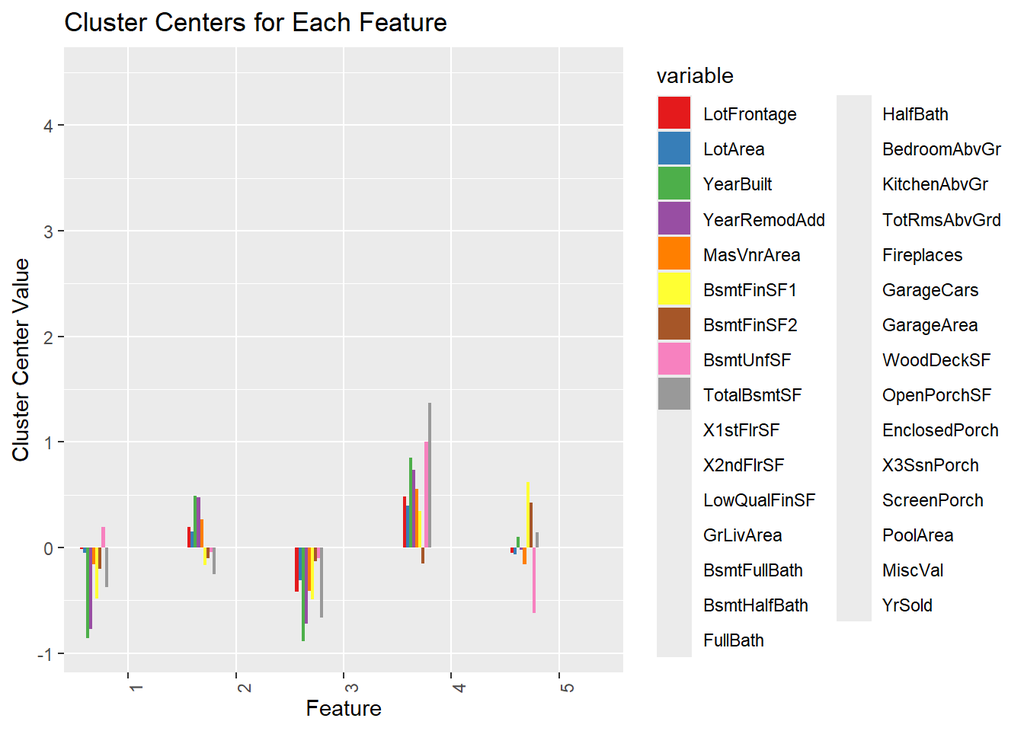

```r
# Convert the cluster centers to a data frame for easier visualization
centers_df <- as.data.frame(centers)

# Create a bar plot of the feature ranges across clusters
library(ggplot2)

centers_df$Feature <- rownames(centers_df)
centers_df_long <- reshape2::melt(centers_df, id.vars = "Feature")

ggplot(centers_df_long, aes(x = Feature, y = value, fill = variable)) +
  geom_bar(stat = "identity", position = "dodge") +
  labs(title = "Cluster Centers for Each Feature", x = "Feature", y = "Cluster Center Value") +
  theme(axis.text.x = element_text(angle = 90, hjust = 1)) +
  scale_fill_brewer(palette = "Set1")
```

# Artificial Neural Networks

## Partition Dataset

```r
# Designate a shortened name MLP for the MultilayerPercentron ANN method in RWeka
MLP <- make_Weka_classifier("weka/classifiers/functions/MultilayerPerceptron")

# Partititon Dataset via 80/20 split
set.seed(100)
row_indices <- createDataPartition(hpc$SalePrice,p=0.8,list=FALSE)

# Assign rows to train and test set respectively
train_set <- hpc_01[row_indices,] # 80% of data should be in train
test_set <- hpc_01[-row_indices,] # 20 % of data should be in test

nrow(train_set) # Display Number of rows
```

```
## [1] 1153
```

```r
nrow(test_set) # Display Number of rows
```

```
## [1] 286
```

```r
total_rows <- nrow(train_set) + nrow(test_set)
total_rows
```

```
## [1] 1439
```

The partition is successful, the number of rows from the train set (1153) and the test set(286) is equal to 1439 rows.

## Set up Cores

```r
num_cores <- detectCores()
num_cores <- num_cores - 1
```

Cores will be setup to help with processing models faster.

## First Model

```r
tic()
doParallel::registerDoParallel(cores = num_cores)
ANN_00 <- MLP(SalePrice ~ . , data = train_set)
toc()
```

```
## 443.53 sec elapsed
```

### Generate Predictions and Metrics

```r
# Generate Predictions
#tr = train
ANN_00_train <- predict(ANN_00,newdata = train_set)
# te = test
ANN_00_test <- predict(ANN_00, test_set)

# In the Weka model, there are default paramters which are list down below
#l <- 0.3 - learn rate
#m <- 0.2 - momentum
#n <-500 - number of epochs/passes
#h <- 'a' - #The hidden nodes to be created on each layer:
  # an integer, or the letters 'a' = (# of attribs + # of classes) / 2,
  #'i' = # of attribs, 'o' = # of classes, 't' = (# of attribs + # of classes)
  # default of H is 'a'.
```

### Train Metrics

```r
ANN_00_tr_met <- mmetric(train_set$SalePrice,ANN_00_train,metric = metrics_list)
round_metrics(ANN_00_tr_met)
```

```
## $MAE
## [1] 15404.57
##
## $RMSE
## [1] 18087.08
##
## $R2
## [1] 0.97
##
## $COR
## [1] 0.99
##
## $MAPE
## [1] 9.41
##
## $RMSPE
## [1] 1.11
##
## $RAE
## [1] 27.21
##
## $RRSE
## [1] 23.41
```

### Test Metrics

```r
ANN_00_te_met <- mmetric(test_set$SalePrice,ANN_00_test,metric = metrics_list)
round_metrics(ANN_00_te_met)
```

```
## $MAE
## [1] 27321.19
##
## $RMSE
## [1] 37500.45
##
## $R2
## [1] 0.8
##
## $COR
## [1] 0.9
##
## $MAPE
## [1] 15.1
##
## $RMSPE
## [1] 1.93
##
## $RAE
## [1] 48.91
##
## $RRSE
## [1] 47.73
```

This means that the model is picking up on noise in the data and is very complicated. A potential reason could be that the model has 171 hidden nodes on 1 layer.

## Second Model

```r
# These are the default values for MLP, except for h
l <- 0.3
m <- 0.2
n <-500
h <- '86' # Split the number of hidden nodes by half (171/2)
# 86 means 1 layer with 86 nodes

tic()
doParallel::registerDoParallel(cores = num_cores)
ANN_02 <- MLP(SalePrice ~ . , data = train_set,control= Weka_control(L = l, M = m, N = n, H = h))
toc()
```

```
## 259.18 sec elapsed
```

```r
summary(ANN_02)
```

```
##
## === Summary ===
##
## Correlation coefficient                  0.9897
## Mean absolute error                   8734.2005
## Root mean squared error              11225.2304
## Relative absolute error                 15.4286 %
## Root relative squared error             14.5264 %
## Total Number of Instances             1153
```

Since the first model moderately overfit, we’ll attempt to simplify this model by reducing the number of nodes on the hidden layer. We can do this by cutting the number of nodes in half. If one looks at the first model there were 171 nodes, so we’ll cut this in half and train the model.

### Generate Predictions and Train Metrics

```r
ANN_02_train <- predict(ANN_02,newdata = train_set)
ANN_02_test <- predict(ANN_02,newdata= test_set)

ANN_02_tr_met <- mmetric(train_set$SalePrice,ANN_02_train,metric = metrics_list)
round_metrics(ANN_02_tr_met)
```

```
## $MAE
## [1] 7959.22
##
## $RMSE
## [1] 10197.32
##
## $R2
## [1] 0.98
##
## $COR
## [1] 0.99
##
## $MAPE
## [1] 5.01
##
## $RMSPE
## [1] 0.68
##
## $RAE
## [1] 14.06
##
## $RRSE
## [1] 13.2
```

### Test Metrics

```r
ANN_02_te_met <- mmetric(test_set$SalePrice,ANN_02_test,metric = metrics_list)
round_metrics(ANN_02_te_met)
```

```
## $MAE
## [1] 25167.33
##
## $RMSE
## [1] 37369.47
##
## $R2
## [1] 0.78
##
## $COR
## [1] 0.88
##
## $MAPE
## [1] 14.19
##
## $RMSPE
## [1] 2.05
##
## $RAE
## [1] 45.06
##
## $RRSE
## [1] 47.57
```

Reducing the nodes by half on the hidden layer has caused the model to overfit even more severely.

## Grid Search

It’s quite apparent based of the previous neural networks that there are several different hyper-parameters from the Learn and Momentum Rates to the number of hidden nodes. It would take an incredibly long time to experiment with all of these hyper-parameters to find a model that is generalizable.

Some of the hyper-parameters cause the model to severely underfit while other hyper-parameters cause the model to overfit.

It’s also very computationally expensive to experiment and select the model with the best hyper-parameters. Thus a more efficient method is required to find a model that generalizes well to new data and does not or underfit.

This method is Grid Search which we can use to find a model that generalizes well to new data. Grid-Search will search through various hyperparameter combinations, till it finds the best model based on a metric that we specify.

### AVNET

We’ll try AVNET with the decay parameters to see if the model performance can be improved. The decay parameters act as regularization a parameter to prevent overfitting.

The implementation of AVNET also involves grid search.

```r
train_predictor <- train_set[,-79] # SalePrice is col 80 in data-set
train_outcome <- train_set [,79]

test_predictor <- test_set[,-79]
test_outcome <- test_set[,79]


ctrl <- trainControl(method = "repeatedcv",   # cross-validation
                     number = 5,               # 5 folds
                     repeats = 5,              # 5 repetitions
                     savePredictions = "all"   # Save all predictions to help with diagnostics
)

avnnetGrid <- expand.grid(decay = c(.001,.005),
size = c(1:6),
bag = FALSE
)

tic()
doParallel::registerDoParallel(cores = num_cores)
avnnet_fit <- train(train_predictor, train_outcome,
method = "avNNet",
tuneGrid = avnnetGrid,
trControl = ctrl,
#preProc = c("center", "scale"),
trace = FALSE,
metric= "RMSE",
allowParallel=TRUE,
maxit = 100)
toc()
```

```
## 32.54 sec elapsed
```

This grid search was alright however the model is unable to perform a more complex grid search with more nodes. (If we try a size of 10-20, the algorithm starts to crash)

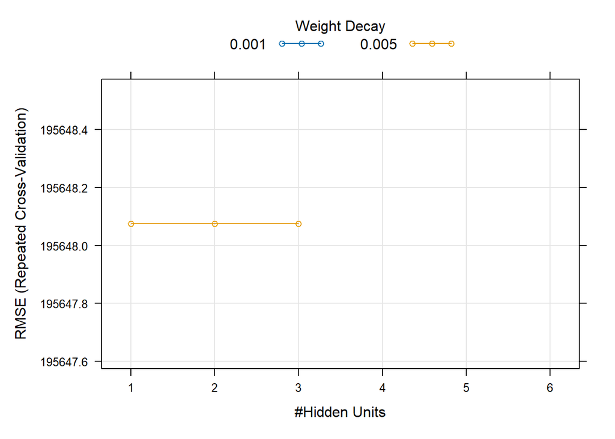

```r
plot(avnnet_fit)
```

```r
predicted_outcome <- predict(avnnet_fit, newdata = test_predictor)
# Evaluate performance
metrics <- postResample(pred = predicted_outcome, obs = test_outcome)

# Print the metrics
print(metrics)
```

```
##     RMSE Rsquared      MAE
## 196813.9       NA 180454.6
```

The algorithm was only able to build out 3 models that all had the same RMSE.

- This is probably because AVnet is a lightweight neural net implementation. Thus, a more robust implementation is needed.

### RWeka Grid Search

RWeka is a more robust implementation, that can handle more complex models. Thus, this implementation will be used in combination with Grid Search to find the best hyper-parameters.

#### Implement Grid Search

```r
train_predictor <- train_set[,-79] # SalePrice is col 80 in data-set
train_outcome <- train_set [,79]

test_predictor <- test_set[,-79]
test_outcome <- test_set[,79]
# Define parameter grid
learning_rates <- c(0.1, 0.01, 0.001)
momentums <- c(0.2, 0.5, 0.9)
hidden_layers <- c("5", "10,5", "20","32,64,83")  # Different layer configurations
epochs <- c(100, 200)

# Placeholder for results
results <- data.frame(LearningRate = numeric(),
                      Momentum = numeric(),
                      HiddenLayers = character(),
                      Epochs = numeric(),
                      RMSE = numeric(),
                      stringsAsFactors = TRUE)

# Grid search
tic()
set.seed(100)  # Use this seed for consistency in future work
for (lr in learning_rates) {
  for (mom in momentums) {
    for (hl in hidden_layers) {
      for (epoch in epochs) {

        # Train model with current parameters
        model <- MLP(train_outcome ~ .,
                     data = train_predictor,
                     control = Weka_control(L = lr, M = mom, H = hl, N = epoch))

        # Evaluate performance (e.g., RMSE)
        predictions <- predict(model, test_set)
        rmse <- sqrt(mean((predictions - test_outcome)^2))

        # Store results
        results <- rbind(results, data.frame(
          LearningRate = lr,
          Momentum = mom,
          HiddenLayers = hl,
          Epochs = epoch,
          RMSE = rmse
        ))
      }
    }
  }
}
toc()
```

```
## 1519.11 sec elapsed
```

```r
# Find best parameters
best_model <- results[which.min(results$RMSE), ]
print(best_model)
```

```
##    LearningRate Momentum HiddenLayers Epochs     RMSE
## 69        0.001      0.9           20    100 26198.78
```

#### Calculate Test Metrics

```r
# Extract best parameters
best_lr <- best_model$LearningRate
best_mom <- best_model$Momentum
best_hl <- best_model$HiddenLayers
best_epochs <- best_model$Epochs

# Train the model with the best parameters
final_model <- MLP(train_outcome ~ .,
                   data = train_set,
                   control = Weka_control(L = best_lr, M = best_mom, H = best_hl, N = best_epochs))

final_predictions <- predict(final_model, test_set)

# Calculate RMSE
rmse <- sqrt(mean((final_predictions - test_outcome)^2))

# Calculate R-squared
sse <- sum((final_predictions - test_outcome)^2)  # Sum of Squared Errors
sst <- sum((test_outcome - mean(test_outcome))^2) # Total Sum of Squares
r_squared <- 1 - (sse / sst)

# Calculate MAE
mae <- mean(abs(final_predictions - test_outcome))

# Print metrics
cat("RMSE:", rmse, "\n")
```

```
## RMSE: 21464.91
```

```r
cat("R-squared:", r_squared, "\n")
```

```
## R-squared: 0.9253478
```

```r
cat("MAE:", mae, "\n")
```

```
## MAE: 13322.84
```

#### Calculate Train Set Metrics

```r
train_predictions <- predict(final_model, train_set)

# Calculate RMSE
train_rmse <- sqrt(mean((train_predictions - train_outcome)^2))

# Calculate R-squared
train_sse <- sum((train_predictions - train_outcome)^2)  # Sum of Squared Errors
train_sst <- sum((train_outcome - mean(train_outcome))^2) # Total Sum of Squares
train_r_squared <- 1 - (train_sse / train_sst)

# Calculate MAE
train_mae <- mean(abs(train_predictions - train_outcome))

# Print metrics
cat("Training Set Metrics:\n")
```

```
## Training Set Metrics:
```

```r
cat("RMSE:", train_rmse, "\n")
```

```
## RMSE: 14709.4
```

```r
cat("R-squared:", train_r_squared, "\n")
```

```
## R-squared: 0.9637662
```

```r
cat("MAE:", train_mae, "\n")
```

```
## MAE: 10196.26
```

#### Train vs Test Set Metrics

```r
comparison_metrics <- data.frame(
  Dataset = c("Train", "Test"),
  RMSE = c(train_rmse, rmse),
  Rsquared = c(train_r_squared, r_squared),
  MAE = c(train_mae, mae)
)

print(comparison_metrics)
```

```
##   Dataset     RMSE  Rsquared      MAE
## 1   Train 14709.40 0.9637662 10196.26
## 2    Test 21464.91 0.9253478 13322.84
```

## 5-fold valuation

```r
cv_function_MLP <- function(df, target, nFolds, seedVal, metrics_list, l, m, n, h)
{
# create folds using the assigned values

set.seed(seedVal)
folds = createFolds(df[,target],nFolds)

# The lapply loop

cv_results <- lapply(folds, function(x)
{
# data preparation:

  test_target <- df[x,target]
  test_input <- df[x,-target]

  train_target <- df[-x,target]
  train_input <- df[-x,-target]
  pred_model <- MLP(train_target ~ .,data = train_input,control = Weka_control(L=l,M=m, N=n,H=h))
  pred <- predict(pred_model, test_input)
  return(mmetric(test_target,pred,metrics_list))
})

cv_results_m <- as.matrix(as.data.frame(cv_results))
cv_mean<- as.matrix(rowMeans(cv_results_m))
cv_sd <- as.matrix(rowSds(cv_results_m))
colnames(cv_mean) <- "Mean"
colnames(cv_sd) <- "Sd"
cv_all <- cbind(cv_results_m, cv_mean, cv_sd)
kable(t(cbind(cv_all)),digits=2)
}
```

```r
cv_function_MLP(hpc_01,79,5,100,metrics_list = c("R2","RMSE"),0.001,0.9,100,"20")
```

|  | R2 | RMSE |
| --- | --- | --- |
| Fold1 | 0.90 | 24178.27 |
| Fold2 | 0.91 | 24245.88 |
| Fold3 | 0.79 | 38569.63 |
| Fold4 | 0.92 | 21699.27 |
| Fold5 | 0.89 | 27003.66 |
| Mean | 0.88 | 27139.34 |
| Sd | 0.05 | 6659.66 |

```r
ridge_best_lambda <- cv_ridge$lambda.min
ridge_model <- glmnet(X, y, alpha = 0, lambda = ridge_best_lambda)
```

## Visualizations

### Scatter Plot: Actual vs. Predicted Prices (Test Set)

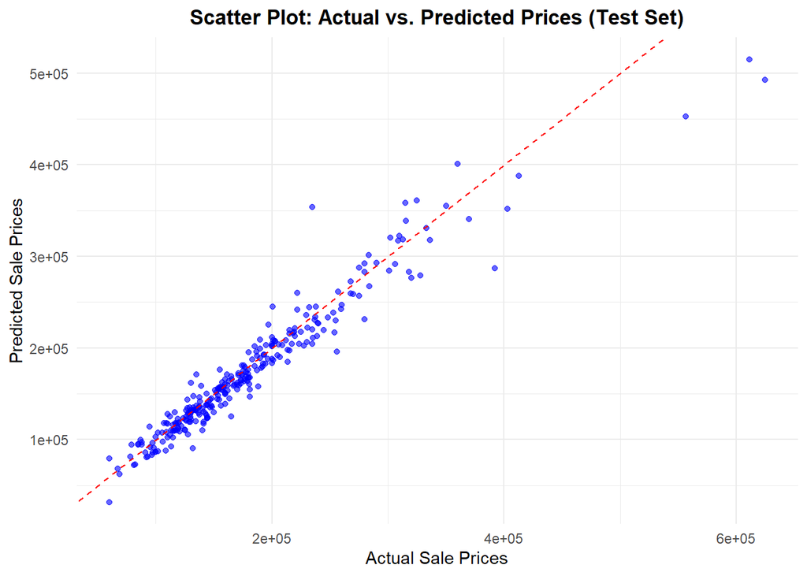

```r
# Scatter Plot: Actual vs. Predicted Prices (Test Set)
scatter_plot <- ggplot(data = data.frame(Actual = test_outcome, Predicted = final_predictions), aes(x = Actual, y = Predicted)) +
  geom_point(color = "blue", alpha = 0.6) +
  geom_abline(slope = 1, intercept = 0, color = "red", linetype = "dashed") +
  labs(title = "Scatter Plot: Actual vs. Predicted Prices (Test Set)",
       x = "Actual Sale Prices",
       y = "Predicted Sale Prices") +
  theme_minimal() +
  theme(plot.title = element_text(hjust = 0.5, face = "bold"))

plot(scatter_plot)
```

Scatter Plot:

It Plots test_outcome (actual values) vs. final_predictions (predicted values). Visual feedback on how well the model’s predictions align with actual values. A tight clustering around the diagonal line indicates a good fit. The diagonal red dashed line indicates perfect predictions. Points close to this line signify accurate predictions.

### Comparison Table

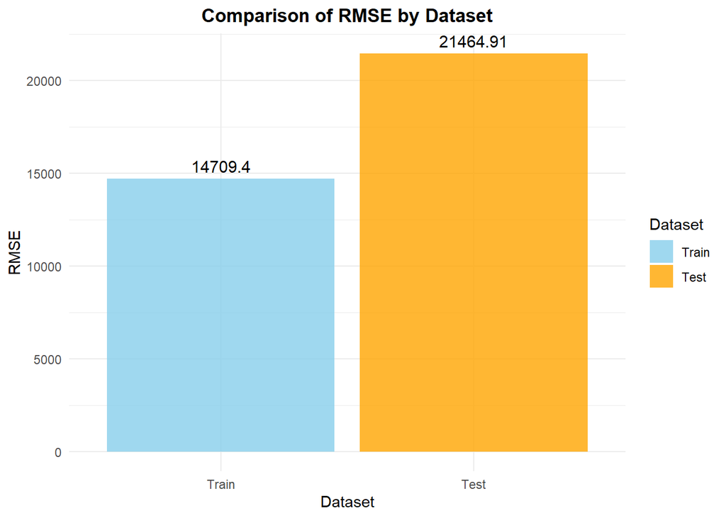

```r
# Comparison Table Visualization

comparison_metrics$Dataset <- factor(comparison_metrics$Dataset, levels = c("Train", "Test"))
comparison_plot <- ggplot(comparison_metrics, aes(x = Dataset)) +
  geom_col(aes(y = RMSE, fill = Dataset), position = position_dodge(width = 0.8), alpha = 0.8) +
  geom_text(aes(y = RMSE, label = round(RMSE, 2)), vjust = -0.5, color = "black", size = 4) +
  labs(title = "Comparison of RMSE by Dataset",
       x = "Dataset",
       y = "RMSE") +
  theme_minimal() +
  theme(plot.title = element_text(hjust = 0.5, face = "bold")) +
  scale_fill_manual(values = c("Train" = "skyblue", "Test" = "orange"))

plot(comparison_plot)
```

Comparison Table Visualization:

Displays the RMSE values for the train and test datasets as bar heights.

It is an intuitive comparison of RMSE for training and testing datasets to check for overfitting or underfitting. It also annotates the bar heights with their corresponding RMSE values for clarity.

## Assumptions, Limitations and Robustness Checks for Artifical Neural Networks

**Assumptions**

Linear Separability in Transformed Space: Although neural networks can capture non-linear patterns, the dataset must contain enough information for meaningful separation of price categories.

Feature Importance: All selected variables are assumed to have predictive relevance. Features like GarageCars and GrLivArea were identified based on prior knowledge and exploratory data analysis.

No Multicollinearity Among Predictors: Preprocessing removed or combined redundant variables to prevent multicollinearity from impacting model performance.

Data Consistency: The relationships between predictors and the target variable are assumed to be consistent over time and across samples.

**Limitations**

Model Interpretability: Neural networks are inherently less interpretable compared to simpler models (e.g., linear regression). Understanding feature contributions requires additional tools like SHAP or LIME.

Computational Cost: avNNET’s lightweight architecture is suitable for small datasets but may struggle with scalability for larger datasets.

Imputation Bias: Imputation methods for missing values (e.g., median for LotFrontage) could introduce bias if missingness is not random.

Limited Generalizability: Results are specific to the Ames, Iowa dataset and may not generalize to other housing markets.

**Robustness Checks**

Cleaning: We chose not to remove any columns except for the ID Column. We additionally added a binary column to more explicitly record whether a house has a garage or not. The model may have trained differently had we decided to remove some columns.

Outlier Cleaning was also relatively conservative, however MLP’s are fairly robust to outliers, thus this shouldn’t be a huge issue.

Cross-Validation: Performed 5-fold cross-validation to evaluate the model’s performance across different subsets of the data.

Alternative Architectures: Compared avNNET results with RWeka’s neural network implementation to validate findings.

Infinite Hyperparamter Combinations: There are multiple different hyperparameter combinations which could be applied. It would be computationally intensive and time consuming to evaluate all these combinations.

# Random Forest

```r
set.seed(100)

# Remove missing values as previous workflows can sometimes reintroduce them
hpc <- hpc %>%
  filter(!is.na(GarageYrBlt))  #removes NA rows

sum(is.na(hpc$GarageYrBlt))
```

```
## [1] 0
```

```r
# Split the data into training and testing sets
hpc_split <- initial_split(hpc, prop = 0.8)
hpc_train <- training(hpc_split)
hpc_test <- testing(hpc_split)


# Create a recipe (add preprocessing steps as needed)
hpc_recipe <- recipe(SalePrice ~ ., data = hpc_train) %>%
  step_normalize(all_numeric_predictors()) %>%  # Normalize numeric predictors
  step_nzv(all_predictors())  # Remove all near-zero variance predictors
```

### Define Model

```r
# Define the Random Forest model
model_hpc <- rand_forest(
  mtry = tune(),   #no .of features
  trees = 100,    #no. of trees
  min_n = 10   #minimum samples
) %>%
  set_mode("regression") %>%  # Regression mode
  set_engine("ranger")
```

### Tuning using cross validation and grid search

```r
# Create cross-validation folds
hpc_folds <- vfold_cv(hpc_train, v = 5)

# Define a workflow
hpc_wf <- workflow() %>%
  add_model(model_hpc) %>%
  add_recipe(hpc_recipe)


# Tune the model using grid search
hpc_tune <- hpc_wf %>%
  tune_grid(
    resamples = hpc_folds,
    grid = 10,
    metrics = yardstick::metric_set(yardstick::rmse, yardstick::rsq)  #Use rmse and rsq
  )
```

### Test set Performance

```r
# Select the best model based on RMSE
best_model_hpc <- hpc_tune %>%
  select_best(metric = "rmse")


# Finalize the workflow with the best model
final_workflow_hpc <- hpc_wf %>%
  finalize_workflow(best_model_hpc)

# Fit the final model on the training data and evaluate on the test set
final_fit_hpc <- final_workflow_hpc %>%
  last_fit(split = hpc_split)


# Collect metrics for the test set
test_metrics <- final_fit_hpc %>%
  collect_metrics()
print("Test Set Metrics:")
```

```
## [1] "Test Set Metrics:"
```

```r
print(test_metrics)
```

```
## # A tibble: 2 × 4
##   .metric .estimator .estimate .config
##   <chr>   <chr>          <dbl> <chr>
## 1 rmse    standard   33348.    Preprocessor1_Model1
## 2 rsq     standard       0.787 Preprocessor1_Model1
```

```r
# Collect predictions for the test set
test_predictions <- final_fit_hpc %>%
  collect_predictions()
```

### Train set Performance

```r
# Extract the finalized model again to evaluate on train set
final_model <- final_workflow_hpc %>%
  fit(data = training(hpc_split))

# Collect predictions for the training set
train_predictions <- predict(final_model, new_data = training(hpc_split)) %>%
  bind_cols(training(hpc_split))

# Calculate metrics for the training set
train_metrics <- train_predictions %>%
  yardstick::metrics(truth = SalePrice, estimate = .pred)
print("Training Set Metrics:")
```

```
## [1] "Training Set Metrics:"
```

```r
print(train_metrics)
```

```
## # A tibble: 3 × 3
##   .metric .estimator .estimate
##   <chr>   <chr>          <dbl>
## 1 rmse    standard   13588.
## 2 rsq     standard       0.975
## 3 mae     standard    8227.
```

The Random Forest model demonstrates strong performance on the training set, with RMSE of 13,587.71, MAE of 8,227.26 and a high R^2 of 0.974, indicating it fits the training data very well. However, its performance on the test set significantly declines, with a much higher RMSE of 33,347.92 and a lower R^2 of 0.786. The model is overfitting the training data. While further tuning could be considered, the current results from multiple models reflect a comprehensive evaluation.

## Visualize Predictions for Test Data

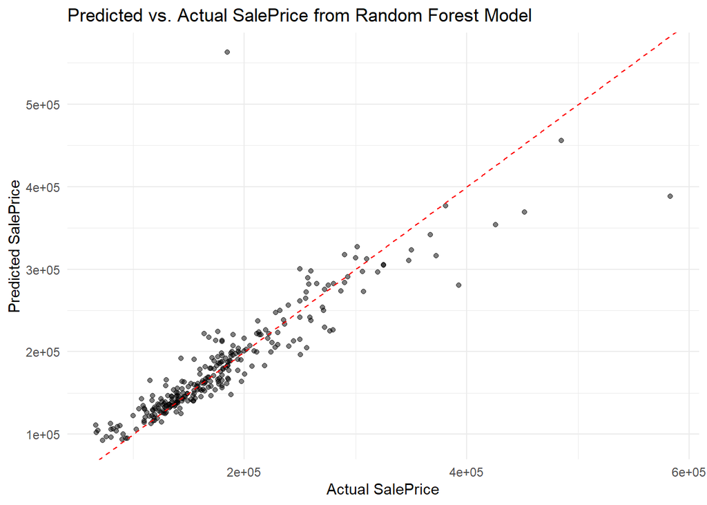

```r
ggplot(test_predictions, aes(x = SalePrice, y = .pred)) +
  geom_point(alpha = 0.5) +
  geom_abline(slope = 1, intercept = 0, color = "red", linetype = "dashed") +
  theme_minimal() +
  labs(title = "Predicted vs. Actual SalePrice from Random Forest Model",
       x = "Actual SalePrice",
       y = "Predicted SalePrice")
```

## Limitations, Assumptions, and Robustness Checks for Random Forest Model

**Limitations:**

1. Random Missing: Removing rows assumes that missingness is random, but if the missing values are systematic (e.g. more frequent in higher or lower SalePrice observations), the results could be biased.
2. Bias-Variance Tradeoff: Reducing training time and computation cost by decreasing the number of trees or folds may increase bias and overlook complex patterns, leading to lower predictive accuracy.
3. Lack of Interpretability: While the model performs decently well on training data, it is difficult to interpret important predictors and decision boundaries from the results.

**Assumptions:**

1. Sufficient Tuning: The chosen hyperparameter ranges assume they sufficiently capture the optimal space for model performance.
2. Non-Linearity: The results from the model are based on a non-linear assumption between predictors and the target variable.
3. No Multicollinearity: As it selects features and observations randomly during tree construction, it is assumed to be robust to multicollinearity.

# Linear Regression Comparison

```r
set.seed(123)

train_rows <- createDataPartition(hpc_01$SalePrice,p = 0.8, list = FALSE)

train_set_01 <- hpc_01[train_rows,]
test_set_01 <- hpc_01[-train_rows,]

vars_to_drop <- c("Condition2","MiscFeature","PoolQC","Exterior1st","Exterior2nd")  # drop variables with different levels

# Drop the variables from the train set
train_set_01 <- train_set_01[, !(colnames(train_set_01) %in% vars_to_drop)]

# Drop the variables from the test set
test_set_01 <- test_set_01[, !(colnames(test_set_01) %in% vars_to_drop)]

m2 <- lm(SalePrice ~ ., data = train_set_01)

m1_te_pred <- predict(m2,newdata=  train_set_01)
m2_te_pred <- predict(m2,newdata = test_set_01)

mmetric(m1_te_pred,train_set_01$SalePrice,metric = c("R2","RMSE"))
```

```
##           R2         RMSE
## 9.284101e-01 2.106820e+04
```

```r
mmetric(m2_te_pred,test_set_01$SalePrice,metric = c("R2","RMSE"))
```

```
##           R2         RMSE
## 8.864826e-01 2.512570e+04
```

This is just a simple linear regression model to estimate a baseline for comparison. Some of the variables had to be dropped like `Exterior1st` which had different levels between the train and test sets. (In other words one of `Exterior1st` levels was in the train set but not the test set. This caused linear regression to have some issues.

However, despite this the model generalizes well to the data with a 4% drop between train and test in $R^2$. The drop in RMSE however is moderate at 4,057 dollars.

The model also does really well, but not quite as well as some of its other counterparts like Elastic Regression or Neural Networks. It however needs variables with a lot of variance, not as robust as the other models.